# PEC1 - Análisis de datos ómicos

Rodrigo Hortal García

2025-04-02

# 1 Resumen

Utilizaremos un conjunto de datos metabolómicos procedentes del siguiente artículo:

Hartman, A. L., Lough, D. M., Barupal, D. K., Fiehn, O., Fishbein, T., Zasloff, M., & Eisen, J. A. (2009). Human gut microbiome adopts an alternative state following small bowel transplantation. Proceedings of the National Academy of Sciences - PNAS, 106(40), 17187–17192. https://doi.org/10.1073/pnas.0904847106

para realizar un análisis metabolómico para ver como afecta el transplante de intestino delgado a la flora intestinal.

# 2 Objetivos

Se quiere estudiar como afecta un transplante de intestino delgado a la flora intestinal. Para ello se analizan los datos metabolómicos de pacientes antes y después de la operación, con el propósito de comprender las alteraciones en la microbiota y los cambios metabólicos asociados.

# 3 Métodos

## 3.1 Origen y naturaleza de los datos.

Se utilizó el conjunto de datos `ST000002` disponible en la plataforma *Metabolomics Workbench*. Estos fueron descargados desde la web en formato de texto `.txt`.

Los datos incluyen:

- 12 muestras (6 antes y 6 después del trasplante)
- 142 metabolitos medidos
- 2 grupos experimentales (antes y después del trasplante)

Al abrir el archivo con un editor, se identificaron tres secciones bien diferenciadas:

- Metadatos del experimento (Filas 0-70): con información general sobre el estudio, incluyendo detalles sobre la institución responsable, el investigador principal y el proyecto.
- Datos de abundancia de metabolitos en muestras (Filas 71-216): esta sección contiene los valores de abundancia de distintos metabolitos en cada muestra:
  - La fila 72 presenta los nombres de las muestras.
  - La fila 73 incluye un factor que indica si la muestra fue tomada antes o después del trasplante.
  - Cada fila posterior representa un metabolito y cada columna una muestra, proporcionando datos cuantitativos sobre la concentración relativa de los metabolitos.
- Información sobre los metabolitos (Filas 217-363): proporciona detalles sobre los metabolitos analizados, incluyendo su nombre, identificadores en bases de datos y otras características relevantes.

## 3.2 Metodología

Para el análisis de los datos seguiremos los siguientes pasos:

- Carga y limpieza de los datos: importándolos en RStudio y eliminando filas y columnas irrelevantes.
- Tratamiento de valores faltantes.
- Normalización: aplicando normalización para reducir el impacto de variaciones técnicas.
- Análisis exploratorio: análisis de componentes principales (PCA) y heatmap para visualizar agrupaciones y tendencias en los datos.
- Análisis univariante: pruebas de t-test para identificar metabolitos significativamente alterados entre los grupos pre y post-trasplante.
- Análisis discriminante de mínimos cuadrados parciales (PLS-DA) para encontrar patrones que permitan diferenciar entre los dos grupos.

## 3.3 Herramientas estadísticas y bioinformáticas

- RStudio (R):
  - Biobase: paquete para gestionar datos genómicos y de expresión en R.
  - metabolomicsWorkbenchR: interfaz para trabajar con datos de la base de datos Metabolomics Workbench.
  - SummarizedExperiment: estructura de datos para almacenar y analizar resultados de experimentos biológicos.
  - POMA: herramienta para normalizar y analizar datos metabolómicos.
  - ggplot2: para visualización.
- Notepad++ para abrir y analizar el archivo de texto con los datos.

# 4 Resultados

Para facilitar el análisis de los datos comenzamos creando un objeto de clase *SummarizedExperiment*. Para ello necesitamos:

- Los datos de expresión (matriz con valores numéricos por muestra).
- Metadatos de filas (información sobre los metabolitos).
- Metadatos de columnas (información sobre las muestras).

```r
# Comenzamos cargando los datos brutos
ruta_archivo <- "/home/hortal/Bioinformatica/Datos omicos/PEC1/Dataset_PEC1/ST000002_AN000002.txt"

datos_brutos <- readLines(ruta_archivo)
```

A continuación, procedemos a extraer toda la información que necesitamos para construir el objeto:

Comenzamos por los resultados numéricos del experimento, descartando para ello los metadatos del archivo:

```r
datos <- read.table(ruta_archivo, skip = 71, nrows = 143, header = TRUE, sep = "\t", quote = "", check.names = FALSE)
# Eliminamos los factores para dejar solo los datos numéricos
datos <- datos[-1,]
```

Separamos las filas con información sobre el experimento:

```r
info_dataset <- read.table(ruta_archivo, skip = 1, nrows = 70, header = FALSE, sep = "\t", quote = "", check.names = FALSE)
```

Creamos tablas con información sobre las muestras y los metabolitos:

```r
info_muestras <- read.table(ruta_archivo, skip = 71, nrows = 1, header = TRUE, sep = "\t", quote = "", check.names = FALSE)
# trasponemos la tabla y convertimos en factor
info_muestras <- as.factor(t(info_muestras[,-1]))

info_metabolitos <- read.table(ruta_archivo, skip = 218, nrows = 142, header = TRUE, sep = "\t", quote = "", check.names = FALSE)
```

Por último, creamos el objeto *SummarizedExperiment*

```r
se <- SummarizedExperiment(
  assays = list(counts = datos[, -1]),
  colData = info_muestras,
  rowData = info_metabolitos,
  metadata = info_dataset
)

colnames(colData(se))[colnames(colData(se)) == "X"] <- "Group"
se
```

```
## class: SummarizedExperiment
## dim: 142 12
## metadata(2): V1 V2
## assays(1): counts
## rownames(142): 2 3 ... 142 143
## rowData names(9): metabolite_name moverz_quant ... other_id
##   other_id_type
## colnames(12): LabF_684508 LabF_684512 ... LabF_684499 LabF_684503
## colData names(1): Group
```

Alternativamente, también podemos descargar el objeto de clase *SummarizedExperiment* directamente desde la base de datos de *Metabolomics Workbench*, utilizando el paquete *metabolomicsWorkbenchR* de *Bioconductor*.

```r
SE = do_query(
    context = 'study',
    input_item = 'study_id',
    input_value = 'ST000002',
    output_item = 'SummarizedExperiment'
)

SE
```

```
## class: SummarizedExperiment
## dim: 142 12
## metadata(8): data_source study_id ... description subject_type
## assays(1): ''
## rownames(142): ME641269 ME641270 ... ME641409 ME641410
## rowData names(3): metabolite_name metabolite_id refmet_name
## colnames(12): LabF_684483 LabF_684487 ... LabF_684524 LabF_684528
## colData names(6): local_sample_id study_id ... raw_data Transplantation
```

La principal diferencia entre esta clase y *ExpressionSet* es su mayor flexibilidad en la información de las filas. Mientras que los *ExpressionSet* usan una estructura fija, los *SummarizedExperiment* permiten usar tanto rangos genómicos (`GRanges`) como `DataFrames` arbitrarios.

## 4.1 Procesamiento y normalización de los datos

Antes de analizar los datos, es importante comprobar y manejar los valores perdidos, ya que pueden afectar los resultados finales:

```r
# Número total de valores faltantes
sum(is.na(assay(SE)))
```

```
## [1] 0
```

En este caso, no se ha encontrado ninguno.

A continuación, para reducir la variabilidad técnica sin reducir la variabilidad biológica, y para facilitar la comparación entre muestras, procedemos con la normalización de los datos. En esta ocasión utilizamos el método de *log_pareto* del paquete `POMA`:

```r
SE_norm <- PomaNorm(SE, method = "log_pareto")
# Mantenemos el nombre de los metabolitos
rownames(SE_norm) <- rownames(SE)
SE_norm
```

```
## class: SummarizedExperiment
## dim: 142 12
## metadata(0):
## assays(1): ''
## rownames(142): ME641269 ME641270 ... ME641409 ME641410
## rowData names(0):
## colnames(12): LabF_684483 LabF_684487 ... LabF_684524 LabF_684528
## colData names(6): local_sample_id study_id ... raw_data Transplantation
```

Con las funciones *PomaBoxplots* y *PomaDensity* visualizamos cómo ha afectado la normalización a los datos. Los *boxplots* del antes y el después muestran cómo cambia la dispersión y los valores atípicos entre las muestras, mientras que las *densidades* nos permiten observar el cambio en las distribuciones de los metabolitos.

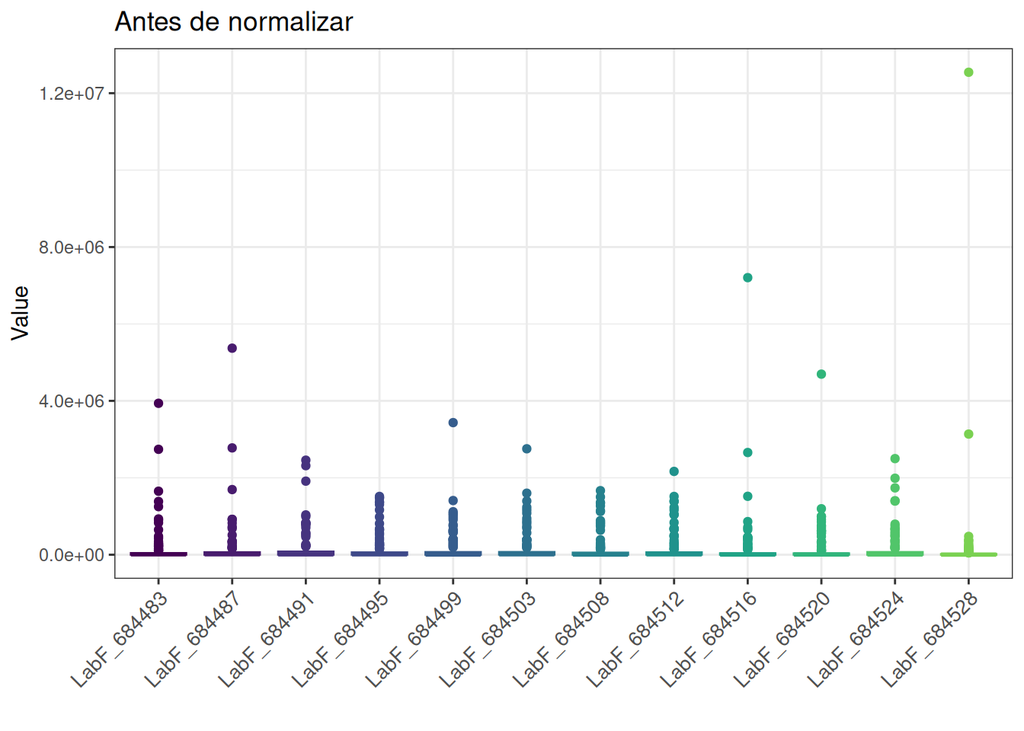

```r
# Datos antes de normalizar
PomaBoxplots(SE, group = "samples",
             jitter = FALSE,
             legend_position = "none") +
  ggplot2::ggtitle("Antes de normalizar")
```

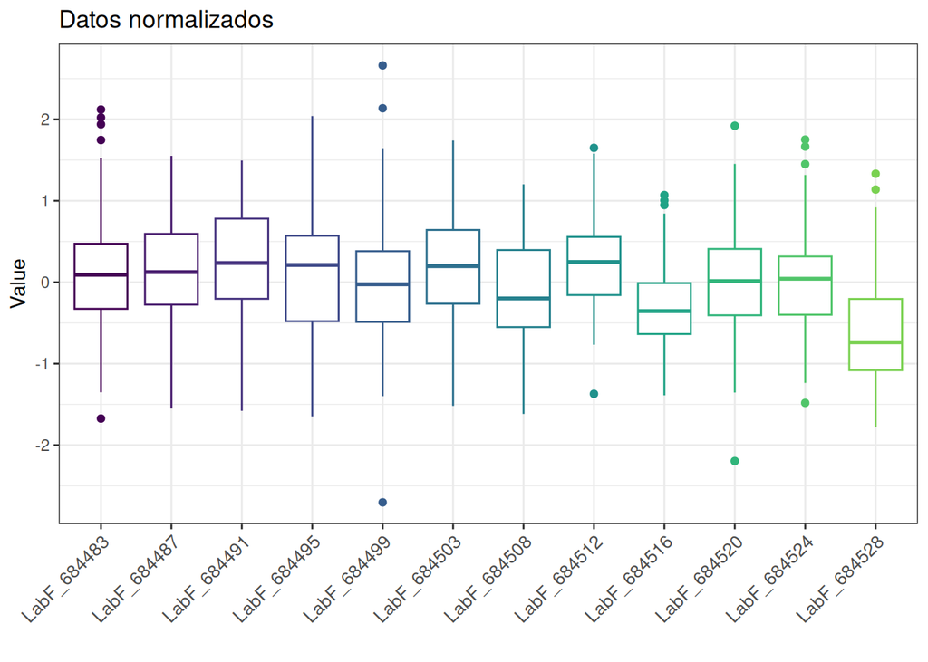

```r
# Datos normalizados
PomaBoxplots(SE_norm,
             group = "samples",
             jitter = FALSE,
             legend_position = "none") +
  ggplot2::ggtitle("Datos normalizados")
```

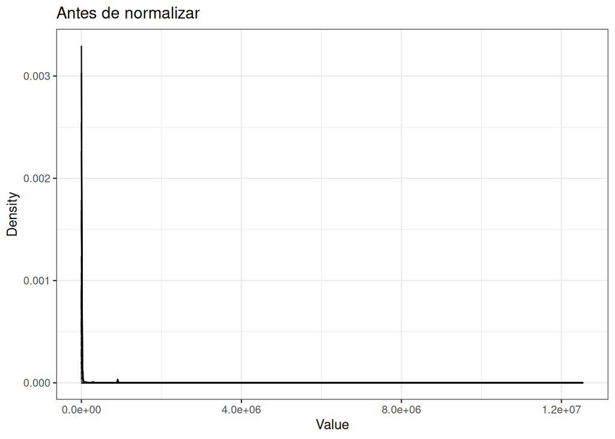

```r
# Datos antes de normalizar
PomaDensity(SE,
            group = "features",
            legend_position = "none") +
  ggplot2::ggtitle("Antes de normalizar")
```

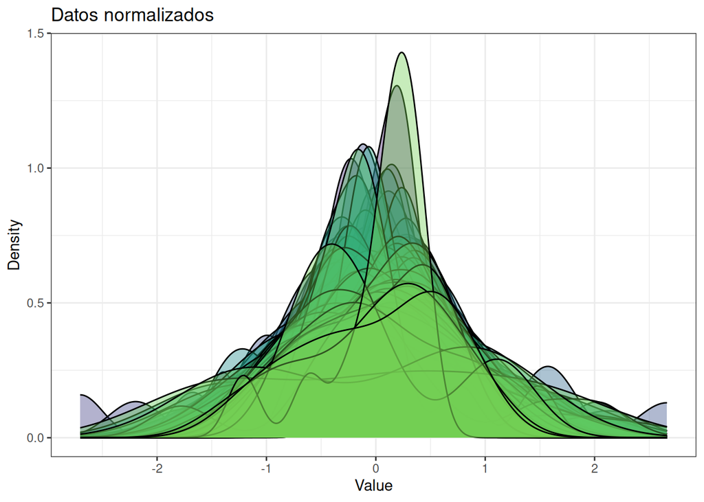

```r
# Datos normalizados
PomaDensity(SE_norm,
            group = "features",
            legend_position = "none") +
  ggplot2::ggtitle("Datos normalizados")
```

Estos análisis visuales nos muestran que la normalización ha logrado reducir la variabilidad no deseada y mejorar la comparabilidad entre las muestras.

Por ultimo detectamos y eliminamos los valores atipicos, ayuda de `PomaOutliers’

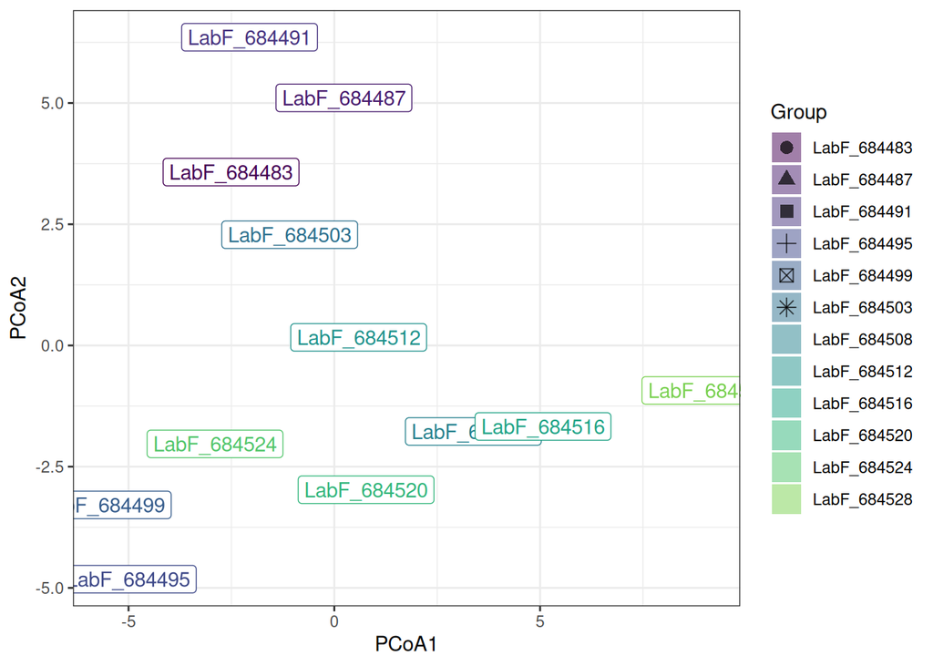

```r
PomaOutliers(SE_norm, do = "analyze")$polygon_plot
```

```r
SE_procesado <- PomaOutliers(SE_norm, do = "clean")
SE_procesado
```

```
## class: SummarizedExperiment
## dim: 142 12
## metadata(0):
## assays(1): ''
## rownames(142): ME641269 ME641270 ... ME641409 ME641410
## rowData names(0):
## colnames(12): LabF_684483 LabF_684487 ... LabF_684524 LabF_684528
## colData names(6): local_sample_id study_id ... raw_data Transplantation
```

Por algún problema en la configuración del *SummarizedExperiment* los grupos no son reconocidos correctamente. Posiblemente por esta razón no es posible ejecutar el resto de test:

## 4.2 Análisis univariante

El análisis univariante utiliza la función *PomaUnivariate()* para realizar un test t y detectar metabolitos con diferencias significativas entre grupos. Por otro lado, *PomaVolcano()* genera un gráfico de volcán que permite visualizar las diferencias significativas y la magnitud del cambio entre los grupos.

```r
PomaUnivariate(SE_procesado, method = "ttest")
PomaVolcano(SE_procesado, pval = "adjusted")
```